# Datenanalyse Bachelor

## 4.2 H2

```r
library(processR)
library(processx)
```

H2a MA ~ OCB, Moderator: Alter

```r
mod_MAOCBAlter <- lm(OCB~MA +   MA*Alter, data = daten)
summary(mod_MAOCBAlter)
```

```
##
## Call:
## lm(formula = OCB ~ MA + MA * Alter, data = daten)
##
## Residuals:
##      Min       1Q   Median       3Q      Max
## -2.45740 -0.32386  0.05936  0.38196  1.57043
##
## Coefficients:
##              Estimate Std. Error t value Pr(>|t|)
## (Intercept)  6.187030   0.592559  10.441   <2e-16 ***
## MA          -0.208710   0.164537  -1.268    0.206
## Alter       -0.012379   0.020574  -0.602    0.548
## MA:Alter     0.002695   0.005661   0.476    0.634
## ---
## Signif. codes:  0 '***' 0.001 '**' 0.01 '*' 0.05 '.' 0.1 ' ' 1
##
## Residual standard error: 0.6316 on 225 degrees of freedom
## Multiple R-squared:  0.03929,    Adjusted R-squared:  0.02648
## F-statistic: 3.067 on 3 and 225 DF,  p-value: 0.02878
```

```r
library(interactions)
```

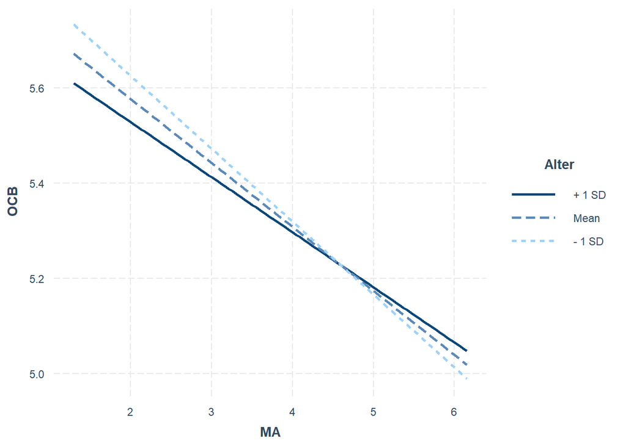

```r
interact_plot(model = mod_MAOCBAlter, pred = MA, modx = Alter)
```

Moderation MA OCB Alter nach process

```r
library(processR)
library(processx)
```

```r
process(data = daten, y = "OCB", x = "MA", w = "Alter", model = 1 )
```

```
## Error in process(data = daten, y = "OCB", x = "MA", w = "Alter", model = 1): konnte Funktion "process" nicht finden
```

H2b NA ~ OCB, Moderator: Alter

```r
mod_NAROCBAlter <- lm(OCB~NAR +  NAR*Alter, data = daten)
summary(mod_NAROCBAlter)
```

```
##
## Call:
## lm(formula = OCB ~ NAR + NAR * Alter, data = daten)
##
## Residuals:
##      Min       1Q   Median       3Q      Max
## -2.00492 -0.26998  0.02488  0.40371  1.60431
##
## Coefficients:
##              Estimate Std. Error t value Pr(>|t|)
## (Intercept)  4.451968   0.749647   5.939 1.08e-08 ***
## NAR          0.257231   0.190623   1.349    0.179
## Alter        0.009064   0.025491   0.356    0.722
## NAR:Alter   -0.003127   0.006540  -0.478    0.633
## ---
## Signif. codes:  0 '***' 0.001 '**' 0.01 '*' 0.05 '.' 0.1 ' ' 1
##
## Residual standard error: 0.6275 on 225 degrees of freedom
## Multiple R-squared:  0.05166,    Adjusted R-squared:  0.03901
## F-statistic: 4.085 on 3 and 225 DF,  p-value: 0.007521
```

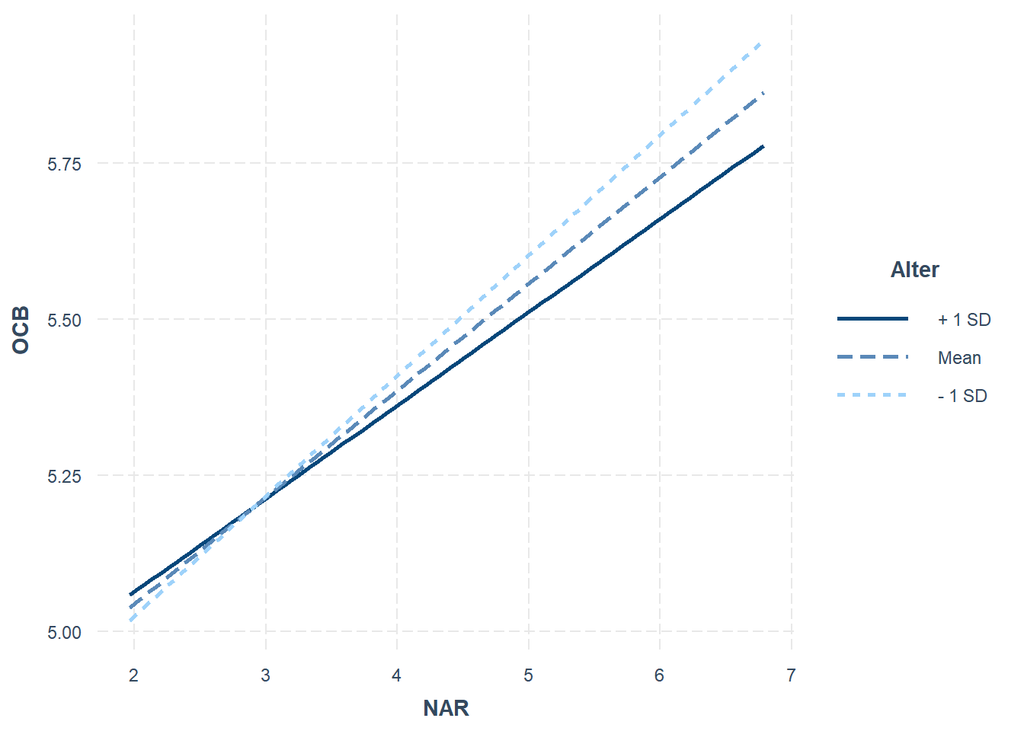

```r
interact_plot(model = mod_NAROCBAlter, pred = NAR, modx = Alter)
```

```r
process(data = daten, y = "OCB", x = "NAR", w = "Alter", model = 1 )
```

```
## Error in process(data = daten, y = "OCB", x = "NAR", w = "Alter", model = 1): konnte Funktion "process" nicht finden
```

H2c PP ~ OCB, Moderator: Alter

```r
mod_PPOCBAlter <- lm(OCB~PP +  PP*Alter, data = daten)
summary(mod_PPOCBAlter)
```

```
##
## Call:
## lm(formula = OCB ~ PP + PP * Alter, data = daten)
##
## Residuals:
##      Min       1Q   Median       3Q      Max
## -2.26286 -0.31036  0.06205  0.37588  1.32130
##
## Coefficients:
##              Estimate Std. Error t value Pr(>|t|)
## (Intercept)  6.035375   0.735142   8.210 1.72e-14 ***
## PP          -0.175694   0.215170  -0.817    0.415
## Alter        0.012301   0.026066   0.472    0.637
## PP:Alter    -0.004115   0.007579  -0.543    0.588
## ---
## Signif. codes:  0 '***' 0.001 '**' 0.01 '*' 0.05 '.' 0.1 ' ' 1
##
## Residual standard error: 0.6029 on 225 degrees of freedom
## Multiple R-squared:  0.1246, Adjusted R-squared:  0.1129
## F-statistic: 10.68 on 3 and 225 DF,  p-value: 1.374e-06
```

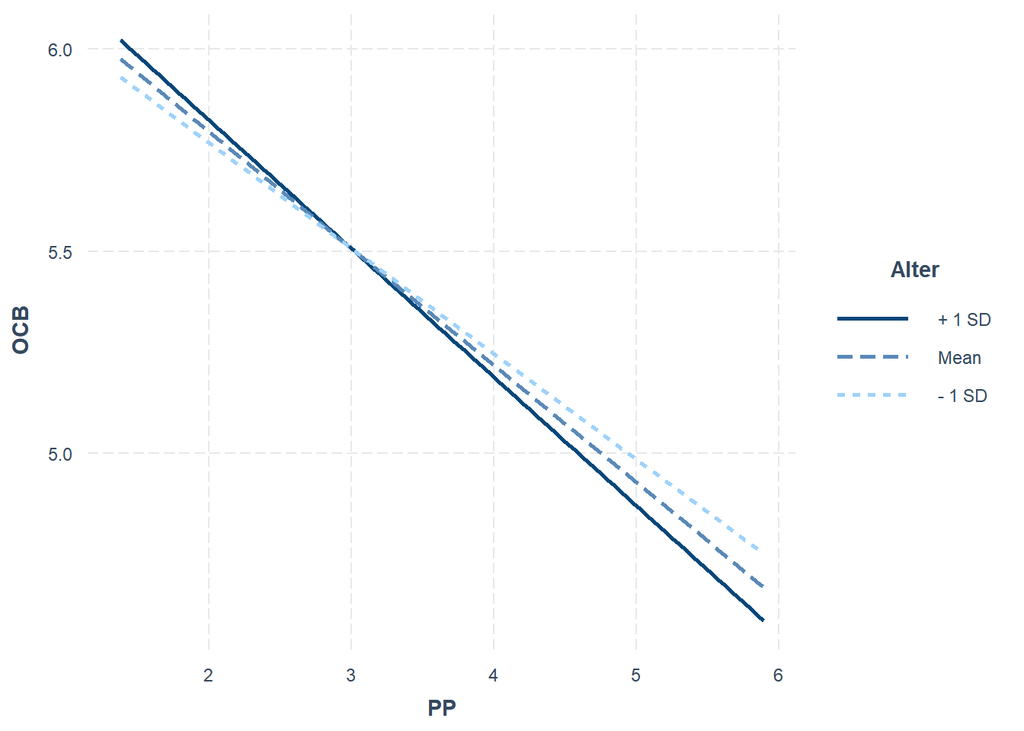

```r
interact_plot(model = mod_PPOCBAlter, pred = PP, modx = Alter)
```

```r
process(data = daten, y = "OCB", x = "PP", w = "Alter", model = 1 )
```

```
## Error in process(data = daten, y = "OCB", x = "PP", w = "Alter", model = 1): konnte Funktion "process" nicht finden
```

## H3 DT ~ Geschlecht

H3a MA ~ OCB, Moderator: Geschlecht

```r
mod_MAOCBGeschlecht <- lm(OCB~MA +   MA*Geschlecht, data = daten)
summary(mod_MAOCBGeschlecht)
```

```
##
## Call:
## lm(formula = OCB ~ MA + MA * Geschlecht, data = daten)
##
## Residuals:
##      Min       1Q   Median       3Q      Max
## -2.48115 -0.30616  0.07493  0.38489  1.59045
##
## Coefficients:
##                       Estimate Std. Error t value Pr(>|t|)
## (Intercept)            5.60256    0.31660  17.696   <2e-16 ***
## MA                    -0.07344    0.08389  -0.875    0.382
## Geschlechtweiblich     0.33116    0.37031   0.894    0.372
## MA:Geschlechtweiblich -0.08409    0.10051  -0.837    0.404
## ---
## Signif. codes:  0 '***' 0.001 '**' 0.01 '*' 0.05 '.' 0.1 ' ' 1
##
## Residual standard error: 0.6311 on 225 degrees of freedom
## Multiple R-squared:  0.04074,    Adjusted R-squared:  0.02795
## F-statistic: 3.185 on 3 and 225 DF,  p-value: 0.02466
```

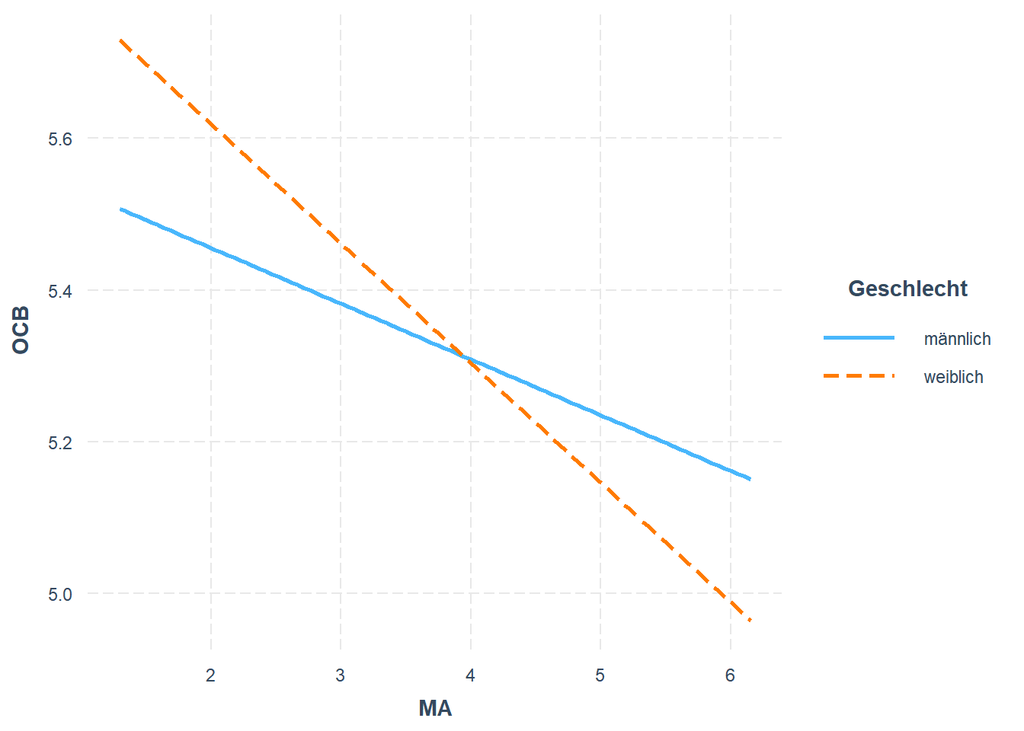

```r
interact_plot(model = mod_MAOCBGeschlecht, pred = MA, modx = Geschlecht)
```

```r
daten2 <- daten
daten2$Geschlecht[daten2$Geschlecht == "männlich"] <- "1" # Beobachtungen den jeweiligen Geschlechtern zuweisen
daten2$Geschlecht[daten2$Geschlecht == "weiblich"] <- "2" # Beobachtungen den jeweiligen Geschlechtern zuweisen
daten2$Geschlecht <- as.numeric(daten2$Geschlecht)
```

```r
process(data = daten2, y = "MA", x = "OCB", w = "Geschlecht", model = 1 )
```

```
## Error in process(data = daten2, y = "MA", x = "OCB", w = "Geschlecht", : konnte Funktion "process" nicht finden
```

H3b NA ~ OCB, Moderator: Geschlecht

```r
mod_NAROCBGeschlecht <- lm(OCB~NAR+ NAR*Geschlecht, data = daten)
summary(mod_NAROCBGeschlecht)
```

```
##
## Call:
## lm(formula = OCB ~ NAR + NAR * Geschlecht, data = daten)
##
## Residuals:
##      Min       1Q   Median       3Q      Max
## -2.02879 -0.29797  0.03141  0.38853  1.59330
##
## Coefficients:
##                        Estimate Std. Error t value Pr(>|t|)
## (Intercept)            4.535238   0.374263  12.118   <2e-16 ***
## NAR                    0.187390   0.086285   2.172   0.0309 *
## Geschlechtweiblich     0.131548   0.448004   0.294   0.7693
## NAR:Geschlechtweiblich 0.005432   0.106736   0.051   0.9595
## ---
## Signif. codes:  0 '***' 0.001 '**' 0.01 '*' 0.05 '.' 0.1 ' ' 1
##
## Residual standard error: 0.6242 on 225 degrees of freedom
## Multiple R-squared:  0.06187,    Adjusted R-squared:  0.04936
## F-statistic: 4.946 on 3 and 225 DF,  p-value: 0.002406
```

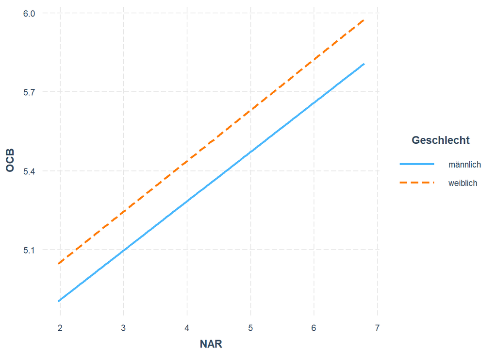

```r
interact_plot(model = mod_NAROCBGeschlecht, pred = NAR, modx = Geschlecht)
```

H3c PP ~ OCB, Moderator Geschlecht

```r
mod_PPOCBGeschlecht <- lm(OCB~PP +   PP*Geschlecht, data = daten)
summary(mod_PPOCBGeschlecht)
```

```
##
## Call:
## lm(formula = OCB ~ PP + PP * Geschlecht, data = daten)
##
## Residuals:
##      Min       1Q   Median       3Q      Max
## -2.26704 -0.31522  0.06524  0.36391  1.32088
##
## Coefficients:
##                       Estimate Std. Error t value Pr(>|t|)
## (Intercept)            6.30425    0.32271  19.535  < 2e-16 ***
## PP                    -0.27563    0.08941  -3.083  0.00231 **
## Geschlechtweiblich     0.09806    0.39055   0.251  0.80198
## PP:Geschlechtweiblich -0.01927    0.10969  -0.176  0.86068
## ---
## Signif. codes:  0 '***' 0.001 '**' 0.01 '*' 0.05 '.' 0.1 ' ' 1
##
## Residual standard error: 0.6032 on 225 degrees of freedom
## Multiple R-squared:  0.1238, Adjusted R-squared:  0.1122
## F-statistic:  10.6 on 3 and 225 DF,  p-value: 1.513e-06
```

H3c abgelehnt, weil p über .05 ist.

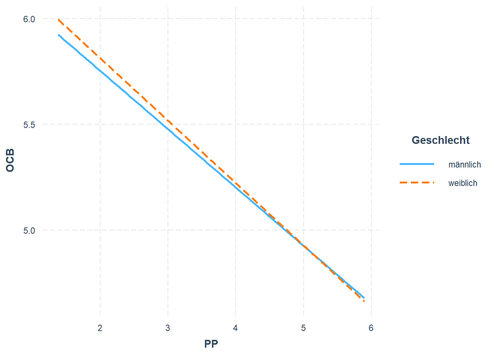

```r
interact_plot(model = mod_PPOCBGeschlecht, pred = PP, modx = Geschlecht)
```

## H4 DT ~ OCB, Moderator: Dauer der Betriebszugehörigkeit (DDB)

H4a MA ~ OCB, Moderator: DDB

```r
mod_MAOCBDDB <- lm(OCB~MA + MA*DDB, data = daten)
summary(mod_MAOCBDDB)
```

```
##
## Call:
## lm(formula = OCB ~ MA + MA * DDB, data = daten)
##
## Residuals:
##      Min       1Q   Median       3Q      Max
## -2.44582 -0.31130  0.05359  0.36234  1.53449
##
## Coefficients:
##              Estimate Std. Error t value Pr(>|t|)
## (Intercept)  5.710152   0.233951  24.407   <2e-16 ***
## MA          -0.082002   0.062616  -1.310    0.192
## DDB          0.026173   0.035628   0.735    0.463
## MA:DDB      -0.009989   0.008917  -1.120    0.264
## ---
## Signif. codes:  0 '***' 0.001 '**' 0.01 '*' 0.05 '.' 0.1 ' ' 1
##
## Residual standard error: 0.6272 on 225 degrees of freedom
## Multiple R-squared:  0.05284,    Adjusted R-squared:  0.04021
## F-statistic: 4.184 on 3 and 225 DF,  p-value: 0.006599
```

```r
process(data = daten, y = "OCB", x = "MA", w = "DDB", model = 1 )
```

```
## Error in process(data = daten, y = "OCB", x = "MA", w = "DDB", model = 1): konnte Funktion "process" nicht finden
```

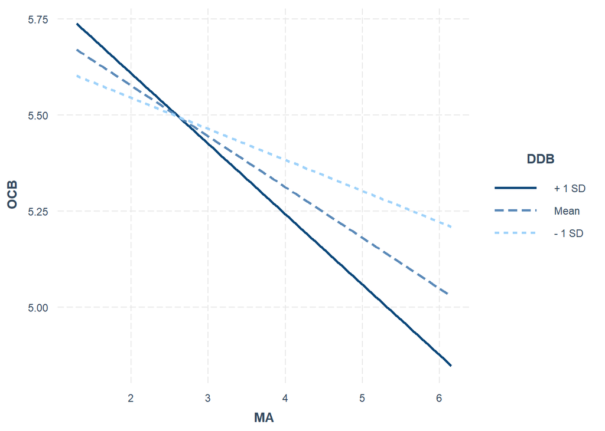

```r
interact_plot(model = mod_MAOCBDDB, pred = MA, modx = DDB)
```

H4a abgelehnt, da p größer ist als .05.

H4b NAR ~ OCB, Moderator: DDB

```r
mod_NAROCBDDB <- lm(OCB~NAR + NAR*DDB, data = daten)
summary(mod_NAROCBDDB)
```

```
##
## Call:
## lm(formula = OCB ~ NAR + NAR * DDB, data = daten)
##
## Residuals:
##      Min       1Q   Median       3Q      Max
## -2.01072 -0.28176  0.01111  0.40219  1.57046
##
## Coefficients:
##              Estimate Std. Error t value Pr(>|t|)
## (Intercept)  4.610999   0.271019  17.014  < 2e-16 ***
## NAR          0.211106   0.066370   3.181  0.00168 **
## DDB          0.020830   0.037302   0.558  0.57711
## NAR:DDB     -0.008661   0.009162  -0.945  0.34548
## ---
## Signif. codes:  0 '***' 0.001 '**' 0.01 '*' 0.05 '.' 0.1 ' ' 1
##
## Residual standard error: 0.623 on 225 degrees of freedom
## Multiple R-squared:  0.06537,    Adjusted R-squared:  0.05291
## F-statistic: 5.246 on 3 and 225 DF,  p-value: 0.001618
```

```r
process(data = daten, y = "OCB", x = "NAR", w = "DDB", model = 1 )
```

```
## Error in process(data = daten, y = "OCB", x = "NAR", w = "DDB", model = 1): konnte Funktion "process" nicht finden
```

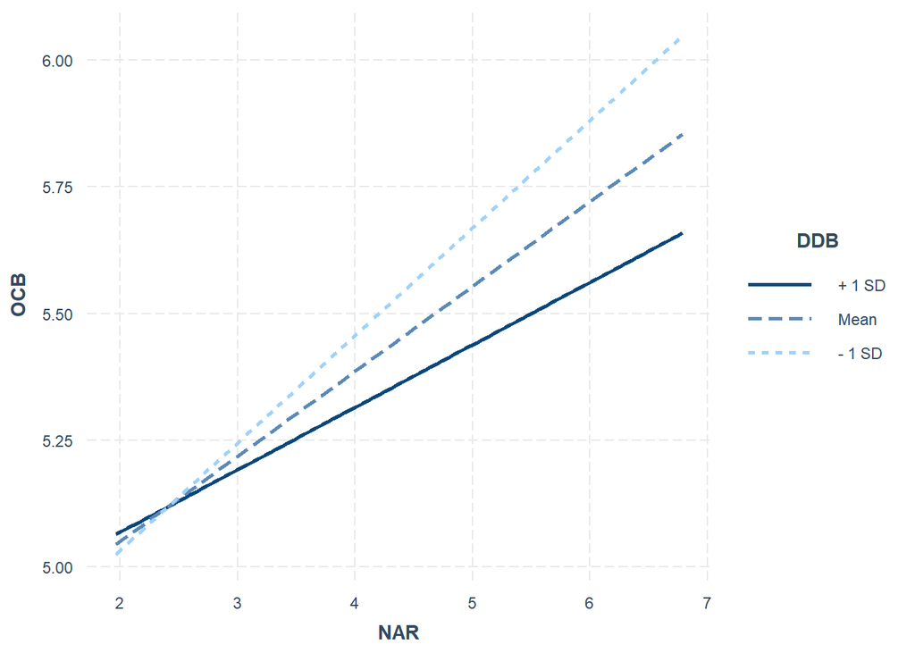

```r
interact_plot(model = mod_NAROCBDDB, pred = NAR, modx = DDB)
```

H4b abgelehnt, wegen Irrtumswahrscheinlichkeit.

H4c PP ~ OCB, Moderator: DDB

```r
mod_PPOCBDDB <- lm(OCB~PP + PP*DDB, data = daten)
summary(mod_PPOCBDDB)
```

```
##
## Call:
## lm(formula = OCB ~ PP + PP * DDB, data = daten)
##
## Residuals:
##      Min       1Q   Median       3Q      Max
## -2.24691 -0.31599  0.04633  0.38204  1.32028
##
## Coefficients:
##              Estimate Std. Error t value Pr(>|t|)
## (Intercept)  6.288929   0.242467  25.937  < 2e-16 ***
## PP          -0.247846   0.067587  -3.667 0.000306 ***
## DDB          0.016004   0.032835   0.487 0.626442
## PP:DDB      -0.007980   0.008795  -0.907 0.365209
## ---
## Signif. codes:  0 '***' 0.001 '**' 0.01 '*' 0.05 '.' 0.1 ' ' 1
##
## Residual standard error: 0.5986 on 225 degrees of freedom
## Multiple R-squared:  0.1371, Adjusted R-squared:  0.1256
## F-statistic: 11.92 on 3 and 225 DF,  p-value: 2.849e-07
```

```r
process(data = daten, y = "OCB", x = "PP", w = "DDB", model = 1 )
```

```
## Error in process(data = daten, y = "OCB", x = "PP", w = "DDB", model = 1): konnte Funktion "process" nicht finden
```

H4c wegen Irrtumswahrscheinlichkeit abgelehnt.

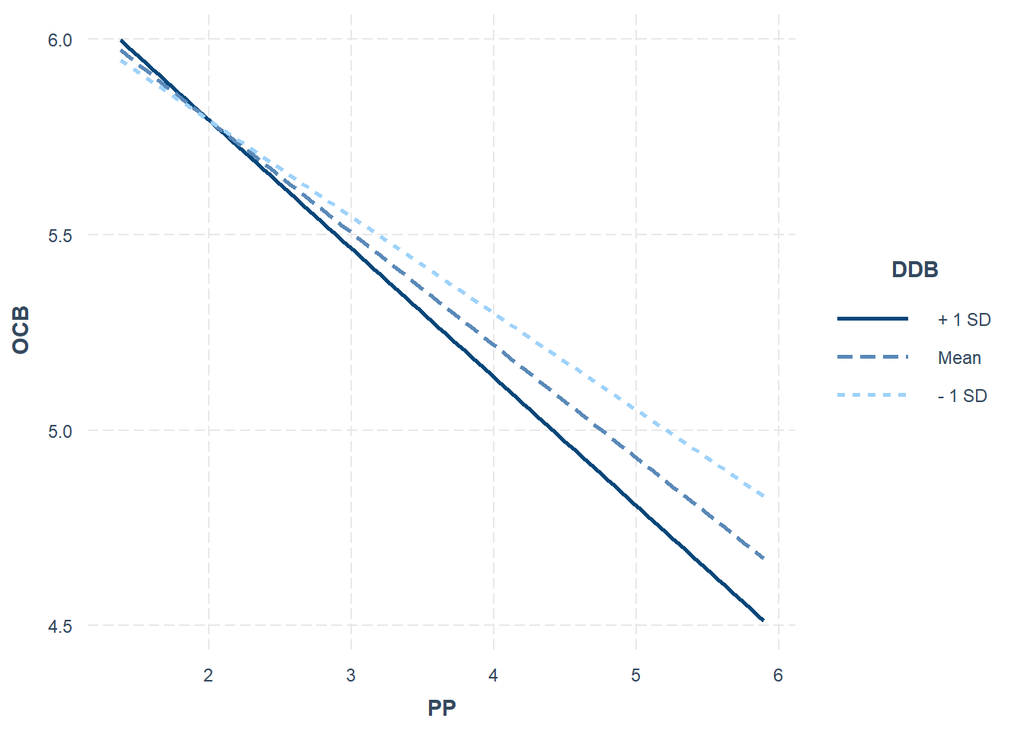

```r
interact_plot(model = mod_PPOCBDDB, pred = PP, modx = DDB)
```

## H5 DT ~ OCB, Mediator: soziale Kompetenzen (SK)

H5a MA ~ OCB, Mediator: SK

```r
process(data = daten, y = "OCB", x = "MA", m = "SK", model = 4)
```

```
## Error in process(data = daten, y = "OCB", x = "MA", m = "SK", model = 4): konnte Funktion "process" nicht finden
```

```r
require(mediation)
MAOCBSK = lm(OCB ~ MA + SK, data = daten)
summary(MAOCBSK)
```

```
##
## Call:
## lm(formula = OCB ~ MA + SK, data = daten)
##
## Residuals:
##      Min       1Q   Median       3Q      Max
## -2.01647 -0.26846  0.04571  0.33738  1.23725
##
## Coefficients:
##             Estimate Std. Error t value Pr(>|t|)
## (Intercept)  2.10064    0.39601   5.305 2.69e-07 ***
## MA          -0.08481    0.03816  -2.223   0.0272 *
## SK           1.24425    0.12361  10.066  < 2e-16 ***
## ---
## Signif. codes:  0 '***' 0.001 '**' 0.01 '*' 0.05 '.' 0.1 ' ' 1
##
## Residual standard error: 0.5242 on 226 degrees of freedom
## Multiple R-squared:  0.3353, Adjusted R-squared:  0.3294
## F-statistic: 56.99 on 2 and 226 DF,  p-value: < 2.2e-16
```

H5b NAR ~ OCB, Mediator: SK

```r
process(data = daten, y = "OCB", x = "NAR", m = "SK", model = 4)
```

```
## Error in process(data = daten, y = "OCB", x = "NAR", m = "SK", model = 4): konnte Funktion "process" nicht finden
```

H5c PP ~, Mediator: SK

```r
process(data = daten, y = "OCB", x = "PP", m = "SK", model = 4)
```

```
## Error in process(data = daten, y = "OCB", x = "PP", m = "SK", model = 4): konnte Funktion "process" nicht finden
```